# Risk Factor Analysis

## Outcome Variable

**Outcome Variable:** ever_stunted

## Predictor Variables

**Intervention Variable:** birthwt

**Adjustment Set:**

unadjusted

## Stratifying Variables

The analysis was stratified on these variable(s):

- agecat
- studyid
- country

## Data Summary

| agecat | studyid | country | A | n | nA | nAY0 | nAY1 |
| --- | --- | --- | --- | --- | --- | --- | --- |
| 3 months | ki0047075b-MAL-ED | BANGLADESH | >=0 | 258 | 34 | 33 | 1 |
| 3 months | ki0047075b-MAL-ED | BANGLADESH | <-3 | 258 | 7 | 0 | 7 |
| 3 months | ki0047075b-MAL-ED | BANGLADESH | [-3–2) | 258 | 38 | 12 | 26 |
| 3 months | ki0047075b-MAL-ED | BANGLADESH | [-2–1) | 258 | 96 | 66 | 30 |
| 3 months | ki0047075b-MAL-ED | BANGLADESH | [-1-0) | 258 | 83 | 72 | 11 |
| 3 months | ki0047075b-MAL-ED | BRAZIL | >=0 | 233 | 128 | 119 | 9 |
| 3 months | ki0047075b-MAL-ED | BRAZIL | <-3 | 233 | 0 | 0 | 0 |
| 3 months | ki0047075b-MAL-ED | BRAZIL | [-3–2) | 233 | 9 | 2 | 7 |
| 3 months | ki0047075b-MAL-ED | BRAZIL | [-2–1) | 233 | 23 | 11 | 12 |
| 3 months | ki0047075b-MAL-ED | BRAZIL | [-1-0) | 233 | 73 | 63 | 10 |
| 3 months | ki0047075b-MAL-ED | INDIA | >=0 | 245 | 44 | 43 | 1 |
| 3 months | ki0047075b-MAL-ED | INDIA | <-3 | 245 | 5 | 0 | 5 |
| 3 months | ki0047075b-MAL-ED | INDIA | [-3–2) | 245 | 24 | 9 | 15 |
| 3 months | ki0047075b-MAL-ED | INDIA | [-2–1) | 245 | 81 | 50 | 31 |
| 3 months | ki0047075b-MAL-ED | INDIA | [-1-0) | 245 | 91 | 77 | 14 |
| 3 months | ki0047075b-MAL-ED | NEPAL | >=0 | 233 | 48 | 48 | 0 |
| 3 months | ki0047075b-MAL-ED | NEPAL | <-3 | 233 | 4 | 0 | 4 |
| 3 months | ki0047075b-MAL-ED | NEPAL | [-3–2) | 233 | 15 | 5 | 10 |
| 3 months | ki0047075b-MAL-ED | NEPAL | [-2–1) | 233 | 55 | 40 | 15 |
| 3 months | ki0047075b-MAL-ED | NEPAL | [-1-0) | 233 | 111 | 103 | 8 |
| 3 months | ki0047075b-MAL-ED | PERU | >=0 | 299 | 93 | 83 | 10 |
| 3 months | ki0047075b-MAL-ED | PERU | <-3 | 299 | 5 | 0 | 5 |
| 3 months | ki0047075b-MAL-ED | PERU | [-3–2) | 299 | 10 | 0 | 10 |
| 3 months | ki0047075b-MAL-ED | PERU | [-2–1) | 299 | 43 | 9 | 34 |
| 3 months | ki0047075b-MAL-ED | PERU | [-1-0) | 299 | 148 | 107 | 41 |
| 3 months | ki0047075b-MAL-ED | SOUTH AFRICA | >=0 | 314 | 113 | 105 | 8 |
| 3 months | ki0047075b-MAL-ED | SOUTH AFRICA | <-3 | 314 | 5 | 0 | 5 |
| 3 months | ki0047075b-MAL-ED | SOUTH AFRICA | [-3–2) | 314 | 16 | 4 | 12 |
| 3 months | ki0047075b-MAL-ED | SOUTH AFRICA | [-2–1) | 314 | 49 | 24 | 25 |
| 3 months | ki0047075b-MAL-ED | SOUTH AFRICA | [-1-0) | 314 | 131 | 99 | 32 |

[output cut: 530 more lines]

The following strata were considered:

- agecat: 12 months, studyid: ki0047075b-MAL-ED, country: BANGLADESH
- agecat: 12 months, studyid: ki0047075b-MAL-ED, country: BRAZIL
- agecat: 12 months, studyid: ki0047075b-MAL-ED, country: INDIA
- agecat: 12 months, studyid: ki0047075b-MAL-ED, country: NEPAL
- agecat: 12 months, studyid: ki0047075b-MAL-ED, country: PERU
- agecat: 12 months, studyid: ki0047075b-MAL-ED, country: SOUTH AFRICA
- agecat: 12 months, studyid: ki0047075b-MAL-ED, country: TANZANIA, UNITED REPUBLIC OF
- agecat: 12 months, studyid: ki1000108-CMC-V-BCS-2002, country: INDIA
- agecat: 12 months, studyid: ki1000108-IRC, country: INDIA
- agecat: 12 months, studyid: ki1000109-EE, country: PAKISTAN
- agecat: 12 months, studyid: ki1000109-ResPak, country: PAKISTAN
- agecat: 12 months, studyid: ki1017093-NIH-Birth, country: BANGLADESH
- agecat: 12 months, studyid: ki1017093b-PROVIDE, country: BANGLADESH
- agecat: 12 months, studyid: ki1017093c-NIH-Crypto, country: BANGLADESH
- agecat: 12 months, studyid: ki1066203-TanzaniaChild2, country: TANZANIA, UNITED REPUBLIC OF
- agecat: 12 months, studyid: ki1101329-Keneba, country: GAMBIA
- agecat: 12 months, studyid: ki1114097-CMIN, country: BRAZIL
- agecat: 12 months, studyid: ki1114097-CMIN, country: PERU
- agecat: 12 months, studyid: ki1114097-CONTENT, country: PERU
- agecat: 12 months, studyid: ki1126311-ZVITAMBO, country: ZIMBABWE
- agecat: 12 months, studyid: ki1135781-COHORTS, country: GUATEMALA
- agecat: 12 months, studyid: ki1135781-COHORTS, country: INDIA
- agecat: 12 months, studyid: ki1135781-COHORTS, country: PHILIPPINES
- agecat: 18 months, studyid: ki0047075b-MAL-ED, country: BANGLADESH
- agecat: 18 months, studyid: ki0047075b-MAL-ED, country: BRAZIL
- agecat: 18 months, studyid: ki0047075b-MAL-ED, country: INDIA
- agecat: 18 months, studyid: ki0047075b-MAL-ED, country: NEPAL
- agecat: 18 months, studyid: ki0047075b-MAL-ED, country: PERU
- agecat: 18 months, studyid: ki0047075b-MAL-ED, country: SOUTH AFRICA
- agecat: 18 months, studyid: ki0047075b-MAL-ED, country: TANZANIA, UNITED REPUBLIC OF
- agecat: 18 months, studyid: ki1000108-CMC-V-BCS-2002, country: INDIA
- agecat: 18 months, studyid: ki1000108-IRC, country: INDIA
- agecat: 18 months, studyid: ki1000109-EE, country: PAKISTAN
- agecat: 18 months, studyid: ki1000109-ResPak, country: PAKISTAN
- agecat: 18 months, studyid: ki1017093-NIH-Birth, country: BANGLADESH
- agecat: 18 months, studyid: ki1017093b-PROVIDE, country: BANGLADESH
- agecat: 18 months, studyid: ki1017093c-NIH-Crypto, country: BANGLADESH
- agecat: 18 months, studyid: ki1066203-TanzaniaChild2, country: TANZANIA, UNITED REPUBLIC OF
- agecat: 18 months, studyid: ki1101329-Keneba, country: GAMBIA
- agecat: 18 months, studyid: ki1114097-CMIN, country: BRAZIL
- agecat: 18 months, studyid: ki1114097-CMIN, country: PERU
- agecat: 18 months, studyid: ki1114097-CONTENT, country: PERU
- agecat: 18 months, studyid: ki1126311-ZVITAMBO, country: ZIMBABWE
- agecat: 18 months, studyid: ki1135781-COHORTS, country: GUATEMALA
- agecat: 18 months, studyid: ki1135781-COHORTS, country: PHILIPPINES
- agecat: 24 months, studyid: ki0047075b-MAL-ED, country: BANGLADESH
- agecat: 24 months, studyid: ki0047075b-MAL-ED, country: BRAZIL
- agecat: 24 months, studyid: ki0047075b-MAL-ED, country: INDIA
- agecat: 24 months, studyid: ki0047075b-MAL-ED, country: NEPAL
- agecat: 24 months, studyid: ki0047075b-MAL-ED, country: PERU
- agecat: 24 months, studyid: ki0047075b-MAL-ED, country: SOUTH AFRICA
- agecat: 24 months, studyid: ki0047075b-MAL-ED, country: TANZANIA, UNITED REPUBLIC OF
- agecat: 24 months, studyid: ki1000108-CMC-V-BCS-2002, country: INDIA
- agecat: 24 months, studyid: ki1000108-IRC, country: INDIA
- agecat: 24 months, studyid: ki1000109-EE, country: PAKISTAN
- agecat: 24 months, studyid: ki1017093-NIH-Birth, country: BANGLADESH
- agecat: 24 months, studyid: ki1017093b-PROVIDE, country: BANGLADESH
- agecat: 24 months, studyid: ki1017093c-NIH-Crypto, country: BANGLADESH
- agecat: 24 months, studyid: ki1066203-TanzaniaChild2, country: TANZANIA, UNITED REPUBLIC OF
- agecat: 24 months, studyid: ki1101329-Keneba, country: GAMBIA
- agecat: 24 months, studyid: ki1114097-CMIN, country: BRAZIL
- agecat: 24 months, studyid: ki1114097-CMIN, country: PERU
- agecat: 24 months, studyid: ki1114097-CONTENT, country: PERU
- agecat: 24 months, studyid: ki1126311-ZVITAMBO, country: ZIMBABWE
- agecat: 24 months, studyid: ki1135781-COHORTS, country: GUATEMALA
- agecat: 24 months, studyid: ki1135781-COHORTS, country: PHILIPPINES
- agecat: 3 months, studyid: ki0047075b-MAL-ED, country: BANGLADESH
- agecat: 3 months, studyid: ki0047075b-MAL-ED, country: BRAZIL
- agecat: 3 months, studyid: ki0047075b-MAL-ED, country: INDIA
- agecat: 3 months, studyid: ki0047075b-MAL-ED, country: NEPAL
- agecat: 3 months, studyid: ki0047075b-MAL-ED, country: PERU
- agecat: 3 months, studyid: ki0047075b-MAL-ED, country: SOUTH AFRICA
- agecat: 3 months, studyid: ki0047075b-MAL-ED, country: TANZANIA, UNITED REPUBLIC OF
- agecat: 3 months, studyid: ki1000108-CMC-V-BCS-2002, country: INDIA
- agecat: 3 months, studyid: ki1000108-IRC, country: INDIA
- agecat: 3 months, studyid: ki1000109-EE, country: PAKISTAN
- agecat: 3 months, studyid: ki1000109-ResPak, country: PAKISTAN
- agecat: 3 months, studyid: ki1017093-NIH-Birth, country: BANGLADESH
- agecat: 3 months, studyid: ki1017093b-PROVIDE, country: BANGLADESH
- agecat: 3 months, studyid: ki1017093c-NIH-Crypto, country: BANGLADESH
- agecat: 3 months, studyid: ki1066203-TanzaniaChild2, country: TANZANIA, UNITED REPUBLIC OF
- agecat: 3 months, studyid: ki1101329-Keneba, country: GAMBIA
- agecat: 3 months, studyid: ki1114097-CMIN, country: BANGLADESH
- agecat: 3 months, studyid: ki1114097-CMIN, country: BRAZIL
- agecat: 3 months, studyid: ki1114097-CMIN, country: PERU
- agecat: 3 months, studyid: ki1114097-CONTENT, country: PERU
- agecat: 3 months, studyid: ki1126311-ZVITAMBO, country: ZIMBABWE
- agecat: 3 months, studyid: ki1135781-COHORTS, country: GUATEMALA
- agecat: 3 months, studyid: ki1135781-COHORTS, country: INDIA
- agecat: 3 months, studyid: ki1135781-COHORTS, country: PHILIPPINES
- agecat: 6 months, studyid: ki0047075b-MAL-ED, country: BANGLADESH
- agecat: 6 months, studyid: ki0047075b-MAL-ED, country: BRAZIL
- agecat: 6 months, studyid: ki0047075b-MAL-ED, country: INDIA
- agecat: 6 months, studyid: ki0047075b-MAL-ED, country: NEPAL
- agecat: 6 months, studyid: ki0047075b-MAL-ED, country: PERU
- agecat: 6 months, studyid: ki0047075b-MAL-ED, country: SOUTH AFRICA
- agecat: 6 months, studyid: ki0047075b-MAL-ED, country: TANZANIA, UNITED REPUBLIC OF
- agecat: 6 months, studyid: ki1000108-CMC-V-BCS-2002, country: INDIA
- agecat: 6 months, studyid: ki1000108-IRC, country: INDIA
- agecat: 6 months, studyid: ki1000109-EE, country: PAKISTAN
- agecat: 6 months, studyid: ki1000109-ResPak, country: PAKISTAN
- agecat: 6 months, studyid: ki1017093-NIH-Birth, country: BANGLADESH
- agecat: 6 months, studyid: ki1017093b-PROVIDE, country: BANGLADESH
- agecat: 6 months, studyid: ki1017093c-NIH-Crypto, country: BANGLADESH
- agecat: 6 months, studyid: ki1066203-TanzaniaChild2, country: TANZANIA, UNITED REPUBLIC OF
- agecat: 6 months, studyid: ki1101329-Keneba, country: GAMBIA
- agecat: 6 months, studyid: ki1114097-CMIN, country: BRAZIL
- agecat: 6 months, studyid: ki1114097-CMIN, country: PERU
- agecat: 6 months, studyid: ki1114097-CONTENT, country: PERU
- agecat: 6 months, studyid: ki1126311-ZVITAMBO, country: ZIMBABWE
- agecat: 6 months, studyid: ki1135781-COHORTS, country: GUATEMALA
- agecat: 6 months, studyid: ki1135781-COHORTS, country: PHILIPPINES

### Dropped Strata

Some strata were dropped due to rare outcomes:

- agecat: 3 months, studyid: ki0047075b-MAL-ED, country: BANGLADESH
- agecat: 3 months, studyid: ki0047075b-MAL-ED, country: BRAZIL
- agecat: 3 months, studyid: ki0047075b-MAL-ED, country: INDIA
- agecat: 3 months, studyid: ki0047075b-MAL-ED, country: NEPAL
- agecat: 3 months, studyid: ki0047075b-MAL-ED, country: PERU
- agecat: 3 months, studyid: ki0047075b-MAL-ED, country: SOUTH AFRICA
- agecat: 3 months, studyid: ki0047075b-MAL-ED, country: TANZANIA, UNITED REPUBLIC OF
- agecat: 3 months, studyid: ki1000108-CMC-V-BCS-2002, country: INDIA
- agecat: 3 months, studyid: ki1000108-IRC, country: INDIA
- agecat: 3 months, studyid: ki1000109-ResPak, country: PAKISTAN
- agecat: 3 months, studyid: ki1017093-NIH-Birth, country: BANGLADESH
- agecat: 3 months, studyid: ki1017093b-PROVIDE, country: BANGLADESH
- agecat: 3 months, studyid: ki1017093c-NIH-Crypto, country: BANGLADESH
- agecat: 3 months, studyid: ki1114097-CMIN, country: BANGLADESH
- agecat: 3 months, studyid: ki1114097-CMIN, country: BRAZIL
- agecat: 3 months, studyid: ki1114097-CMIN, country: PERU
- agecat: 3 months, studyid: ki1114097-CONTENT, country: PERU
- agecat: 3 months, studyid: ki1135781-COHORTS, country: GUATEMALA
- agecat: 6 months, studyid: ki0047075b-MAL-ED, country: BANGLADESH
- agecat: 6 months, studyid: ki0047075b-MAL-ED, country: BRAZIL
- agecat: 6 months, studyid: ki0047075b-MAL-ED, country: INDIA
- agecat: 6 months, studyid: ki0047075b-MAL-ED, country: NEPAL
- agecat: 6 months, studyid: ki0047075b-MAL-ED, country: PERU
- agecat: 6 months, studyid: ki0047075b-MAL-ED, country: SOUTH AFRICA
- agecat: 6 months, studyid: ki0047075b-MAL-ED, country: TANZANIA, UNITED REPUBLIC OF
- agecat: 6 months, studyid: ki1000108-CMC-V-BCS-2002, country: INDIA
- agecat: 6 months, studyid: ki1000108-IRC, country: INDIA
- agecat: 6 months, studyid: ki1000109-EE, country: PAKISTAN
- agecat: 6 months, studyid: ki1000109-ResPak, country: PAKISTAN
- agecat: 6 months, studyid: ki1017093-NIH-Birth, country: BANGLADESH
- agecat: 6 months, studyid: ki1017093b-PROVIDE, country: BANGLADESH
- agecat: 6 months, studyid: ki1017093c-NIH-Crypto, country: BANGLADESH
- agecat: 6 months, studyid: ki1101329-Keneba, country: GAMBIA
- agecat: 6 months, studyid: ki1114097-CMIN, country: BRAZIL
- agecat: 6 months, studyid: ki1114097-CMIN, country: PERU
- agecat: 6 months, studyid: ki1114097-CONTENT, country: PERU
- agecat: 6 months, studyid: ki1135781-COHORTS, country: GUATEMALA
- agecat: 12 months, studyid: ki0047075b-MAL-ED, country: BANGLADESH
- agecat: 12 months, studyid: ki0047075b-MAL-ED, country: BRAZIL
- agecat: 12 months, studyid: ki0047075b-MAL-ED, country: INDIA
- agecat: 12 months, studyid: ki0047075b-MAL-ED, country: NEPAL
- agecat: 12 months, studyid: ki0047075b-MAL-ED, country: PERU
- agecat: 12 months, studyid: ki0047075b-MAL-ED, country: SOUTH AFRICA
- agecat: 12 months, studyid: ki0047075b-MAL-ED, country: TANZANIA, UNITED REPUBLIC OF
- agecat: 12 months, studyid: ki1000108-CMC-V-BCS-2002, country: INDIA
- agecat: 12 months, studyid: ki1000108-IRC, country: INDIA
- agecat: 12 months, studyid: ki1000109-EE, country: PAKISTAN
- agecat: 12 months, studyid: ki1000109-ResPak, country: PAKISTAN
- agecat: 12 months, studyid: ki1017093-NIH-Birth, country: BANGLADESH
- agecat: 12 months, studyid: ki1017093b-PROVIDE, country: BANGLADESH
- agecat: 12 months, studyid: ki1017093c-NIH-Crypto, country: BANGLADESH
- agecat: 12 months, studyid: ki1066203-TanzaniaChild2, country: TANZANIA, UNITED REPUBLIC OF
- agecat: 12 months, studyid: ki1101329-Keneba, country: GAMBIA
- agecat: 12 months, studyid: ki1114097-CMIN, country: BRAZIL
- agecat: 12 months, studyid: ki1114097-CMIN, country: PERU
- agecat: 12 months, studyid: ki1114097-CONTENT, country: PERU
- agecat: 12 months, studyid: ki1135781-COHORTS, country: GUATEMALA
- agecat: 18 months, studyid: ki0047075b-MAL-ED, country: BANGLADESH
- agecat: 18 months, studyid: ki0047075b-MAL-ED, country: BRAZIL
- agecat: 18 months, studyid: ki0047075b-MAL-ED, country: INDIA
- agecat: 18 months, studyid: ki0047075b-MAL-ED, country: NEPAL
- agecat: 18 months, studyid: ki0047075b-MAL-ED, country: PERU
- agecat: 18 months, studyid: ki0047075b-MAL-ED, country: SOUTH AFRICA
- agecat: 18 months, studyid: ki0047075b-MAL-ED, country: TANZANIA, UNITED REPUBLIC OF
- agecat: 18 months, studyid: ki1000108-CMC-V-BCS-2002, country: INDIA
- agecat: 18 months, studyid: ki1000108-IRC, country: INDIA
- agecat: 18 months, studyid: ki1000109-EE, country: PAKISTAN
- agecat: 18 months, studyid: ki1000109-ResPak, country: PAKISTAN
- agecat: 18 months, studyid: ki1017093-NIH-Birth, country: BANGLADESH
- agecat: 18 months, studyid: ki1017093b-PROVIDE, country: BANGLADESH
- agecat: 18 months, studyid: ki1017093c-NIH-Crypto, country: BANGLADESH
- agecat: 18 months, studyid: ki1066203-TanzaniaChild2, country: TANZANIA, UNITED REPUBLIC OF
- agecat: 18 months, studyid: ki1101329-Keneba, country: GAMBIA
- agecat: 18 months, studyid: ki1114097-CMIN, country: BRAZIL
- agecat: 18 months, studyid: ki1114097-CMIN, country: PERU
- agecat: 18 months, studyid: ki1114097-CONTENT, country: PERU
- agecat: 18 months, studyid: ki1135781-COHORTS, country: GUATEMALA
- agecat: 24 months, studyid: ki0047075b-MAL-ED, country: BANGLADESH
- agecat: 24 months, studyid: ki0047075b-MAL-ED, country: BRAZIL
- agecat: 24 months, studyid: ki0047075b-MAL-ED, country: INDIA
- agecat: 24 months, studyid: ki0047075b-MAL-ED, country: NEPAL
- agecat: 24 months, studyid: ki0047075b-MAL-ED, country: PERU
- agecat: 24 months, studyid: ki0047075b-MAL-ED, country: SOUTH AFRICA
- agecat: 24 months, studyid: ki0047075b-MAL-ED, country: TANZANIA, UNITED REPUBLIC OF
- agecat: 24 months, studyid: ki1000108-CMC-V-BCS-2002, country: INDIA
- agecat: 24 months, studyid: ki1000108-IRC, country: INDIA
- agecat: 24 months, studyid: ki1000109-EE, country: PAKISTAN
- agecat: 24 months, studyid: ki1017093-NIH-Birth, country: BANGLADESH
- agecat: 24 months, studyid: ki1017093b-PROVIDE, country: BANGLADESH
- agecat: 24 months, studyid: ki1017093c-NIH-Crypto, country: BANGLADESH
- agecat: 24 months, studyid: ki1066203-TanzaniaChild2, country: TANZANIA, UNITED REPUBLIC OF
- agecat: 24 months, studyid: ki1101329-Keneba, country: GAMBIA
- agecat: 24 months, studyid: ki1114097-CMIN, country: BRAZIL
- agecat: 24 months, studyid: ki1114097-CMIN, country: PERU
- agecat: 24 months, studyid: ki1114097-CONTENT, country: PERU
- agecat: 24 months, studyid: ki1126311-ZVITAMBO, country: ZIMBABWE
- agecat: 24 months, studyid: ki1135781-COHORTS, country: GUATEMALA
- agecat: 24 months, studyid: ki1135781-COHORTS, country: PHILIPPINES

## Methods Detail

We’re interested in the causal parameters $E[Y_a]$ for all values of $a \in \mathcal{A}$. These parameters represent the mean outcome if, possibly contrary to fact, we intervened to set all units to have $A=a$. Under the randomization and positivity assumptions, these are identified by the statistical parameters $\psi_a=E_W[E_{Y|A,W}(Y|A=a,W)]$. In addition, we’re interested in the mean of $Y$, $E[Y]$ under no intervention (the observed mean). We will estimate these parameters by using SuperLearner to fit the relevant likelihood factors – $E_{Y|A,W}(Y|A=a,W)$ and $p(A=a|W)$, and then updating our likelihood fit using a joint TMLE.

For unadjusted analyses ($W=\{\}$), initial likelihoods were estimated using Lrnr_glm to estimate the simple $E(Y|A)$ and Lrnr_mean to estimate $p(A)$. For adjusted analyses, a small library containing Lrnr_glmnet, Lrnr_xgboost, and Lrnr_mean was used.

Having estimated these parameters, we will then use the delta method to estimate relative risks and attributable risks relative to a prespecified baseline level of $A$.

# Results Detail

## Results Plots

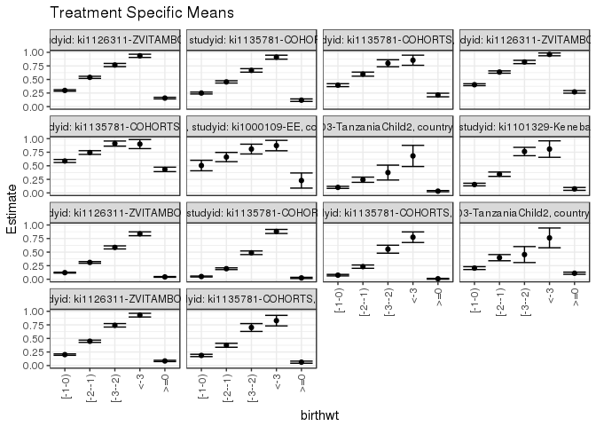

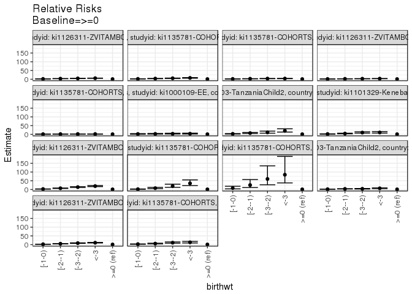

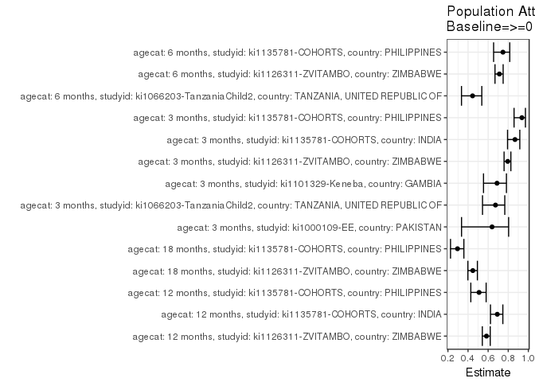

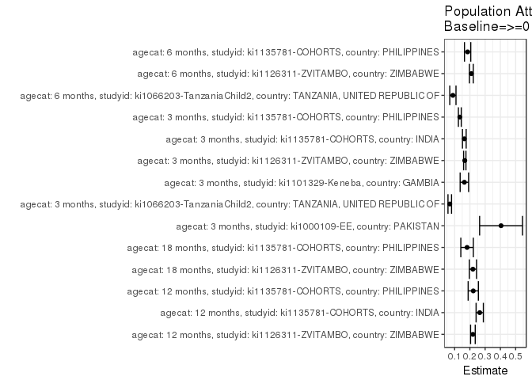

## Results Table

### Parameter: TSM

| agecat | studyid | country | intervention_level | baseline_level | estimate | ci_lower | ci_upper |
| --- | --- | --- | --- | --- | --- | --- | --- |
| 3 months | ki1000109-EE | PAKISTAN | >=0 | NA | 0.2285714 | 0.0892714 | 0.3678715 |
| 3 months | ki1000109-EE | PAKISTAN | <-3 | NA | 0.8723404 | 0.7768088 | 0.9678720 |
| 3 months | ki1000109-EE | PAKISTAN | [-3–2) | NA | 0.8082192 | 0.7177851 | 0.8986533 |
| 3 months | ki1000109-EE | PAKISTAN | [-2–1) | NA | 0.6610169 | 0.5754944 | 0.7465395 |
| 3 months | ki1000109-EE | PAKISTAN | [-1-0) | NA | 0.5048544 | 0.4081698 | 0.6015390 |
| 3 months | ki1066203-TanzaniaChild2 | TANZANIA, UNITED REPUBLIC OF | >=0 | NA | 0.0331384 | 0.0221834 | 0.0440934 |
| 3 months | ki1066203-TanzaniaChild2 | TANZANIA, UNITED REPUBLIC OF | <-3 | NA | 0.6818182 | 0.4871475 | 0.8764888 |
| 3 months | ki1066203-TanzaniaChild2 | TANZANIA, UNITED REPUBLIC OF | [-3–2) | NA | 0.3750000 | 0.2380144 | 0.5119856 |
| 3 months | ki1066203-TanzaniaChild2 | TANZANIA, UNITED REPUBLIC OF | [-2–1) | NA | 0.2434211 | 0.1951697 | 0.2916724 |
| 3 months | ki1066203-TanzaniaChild2 | TANZANIA, UNITED REPUBLIC OF | [-1-0) | NA | 0.1023785 | 0.0832677 | 0.1214892 |
| 3 months | ki1101329-Keneba | GAMBIA | >=0 | NA | 0.0742706 | 0.0477953 | 0.1007458 |
| 3 months | ki1101329-Keneba | GAMBIA | <-3 | NA | 0.8076923 | 0.6561635 | 0.9592211 |
| 3 months | ki1101329-Keneba | GAMBIA | [-3–2) | NA | 0.7627119 | 0.6859337 | 0.8394900 |
| 3 months | ki1101329-Keneba | GAMBIA | [-2–1) | NA | 0.3450185 | 0.3049874 | 0.3850495 |
| 3 months | ki1101329-Keneba | GAMBIA | [-1-0) | NA | 0.1543779 | 0.1303353 | 0.1784205 |
| 3 months | ki1126311-ZVITAMBO | ZIMBABWE | >=0 | NA | 0.0429238 | 0.0359174 | 0.0499302 |
| 3 months | ki1126311-ZVITAMBO | ZIMBABWE | <-3 | NA | 0.8373786 | 0.8017446 | 0.8730127 |
| 3 months | ki1126311-ZVITAMBO | ZIMBABWE | [-3–2) | NA | 0.5866441 | 0.5585820 | 0.6147063 |
| 3 months | ki1126311-ZVITAMBO | ZIMBABWE | [-2–1) | NA | 0.3100798 | 0.2944933 | 0.3256663 |
| 3 months | ki1126311-ZVITAMBO | ZIMBABWE | [-1-0) | NA | 0.1217241 | 0.1133092 | 0.1301391 |
| 3 months | ki1135781-COHORTS | INDIA | >=0 | NA | 0.0250000 | 0.0138994 | 0.0361006 |
| 3 months | ki1135781-COHORTS | INDIA | <-3 | NA | 0.8802817 | 0.8425234 | 0.9180400 |
| 3 months | ki1135781-COHORTS | INDIA | [-3–2) | NA | 0.4878049 | 0.4544146 | 0.5211952 |
| 3 months | ki1135781-COHORTS | INDIA | [-2–1) | NA | 0.1945060 | 0.1781750 | 0.2108370 |
| 3 months | ki1135781-COHORTS | INDIA | [-1-0) | NA | 0.0500808 | 0.0414890 | 0.0586726 |
| 3 months | ki1135781-COHORTS | PHILIPPINES | >=0 | NA | 0.0091743 | 0.0018660 | 0.0164826 |
| 3 months | ki1135781-COHORTS | PHILIPPINES | <-3 | NA | 0.7746479 | 0.6774461 | 0.8718496 |
| 3 months | ki1135781-COHORTS | PHILIPPINES | [-3–2) | NA | 0.5536723 | 0.4804258 | 0.6269188 |
| 3 months | ki1135781-COHORTS | PHILIPPINES | [-2–1) | NA | 0.2323651 | 0.2015748 | 0.2631555 |
| 3 months | ki1135781-COHORTS | PHILIPPINES | [-1-0) | NA | 0.0752533 | 0.0613428 | 0.0891637 |
| 6 months | ki1066203-TanzaniaChild2 | TANZANIA, UNITED REPUBLIC OF | >=0 | NA | 0.1105318 | 0.0906825 | 0.1303811 |
| 6 months | ki1066203-TanzaniaChild2 | TANZANIA, UNITED REPUBLIC OF | <-3 | NA | 0.7619048 | 0.5796988 | 0.9441107 |
| 6 months | ki1066203-TanzaniaChild2 | TANZANIA, UNITED REPUBLIC OF | [-3–2) | NA | 0.4545455 | 0.3073861 | 0.6017049 |
| 6 months | ki1066203-TanzaniaChild2 | TANZANIA, UNITED REPUBLIC OF | [-2–1) | NA | 0.3978873 | 0.3409488 | 0.4548258 |
| 6 months | ki1066203-TanzaniaChild2 | TANZANIA, UNITED REPUBLIC OF | [-1-0) | NA | 0.2053274 | 0.1789458 | 0.2317090 |
| 6 months | ki1126311-ZVITAMBO | ZIMBABWE | >=0 | NA | 0.0849366 | 0.0730993 | 0.0967740 |
| 6 months | ki1126311-ZVITAMBO | ZIMBABWE | <-3 | NA | 0.9288889 | 0.8953050 | 0.9624728 |
| 6 months | ki1126311-ZVITAMBO | ZIMBABWE | [-3–2) | NA | 0.7416201 | 0.7095548 | 0.7736854 |
| 6 months | ki1126311-ZVITAMBO | ZIMBABWE | [-2–1) | NA | 0.4482916 | 0.4274855 | 0.4690976 |
| 6 months | ki1126311-ZVITAMBO | ZIMBABWE | [-1-0) | NA | 0.2015259 | 0.1887727 | 0.2142791 |
| 6 months | ki1135781-COHORTS | PHILIPPINES | >=0 | NA | 0.0626058 | 0.0430713 | 0.0821402 |
| 6 months | ki1135781-COHORTS | PHILIPPINES | <-3 | NA | 0.8275862 | 0.7303551 | 0.9248174 |
| 6 months | ki1135781-COHORTS | PHILIPPINES | [-3–2) | NA | 0.7012987 | 0.6289990 | 0.7735984 |
| 6 months | ki1135781-COHORTS | PHILIPPINES | [-2–1) | NA | 0.3740686 | 0.3374497 | 0.4106874 |
| 6 months | ki1135781-COHORTS | PHILIPPINES | [-1-0) | NA | 0.1866252 | 0.1653273 | 0.2079231 |
| 12 months | ki1126311-ZVITAMBO | ZIMBABWE | >=0 | NA | 0.1570636 | 0.1423297 | 0.1717975 |
| 12 months | ki1126311-ZVITAMBO | ZIMBABWE | <-3 | NA | 0.9358491 | 0.9063471 | 0.9653510 |
| 12 months | ki1126311-ZVITAMBO | ZIMBABWE | [-3–2) | NA | 0.7661188 | 0.7366185 | 0.7956192 |
| 12 months | ki1126311-ZVITAMBO | ZIMBABWE | [-2–1) | NA | 0.5388369 | 0.5191333 | 0.5585406 |
| 12 months | ki1126311-ZVITAMBO | ZIMBABWE | [-1-0) | NA | 0.2980904 | 0.2844083 | 0.3117725 |
| 12 months | ki1135781-COHORTS | INDIA | >=0 | NA | 0.1183673 | 0.0950113 | 0.1417234 |
| 12 months | ki1135781-COHORTS | INDIA | <-3 | NA | 0.9106383 | 0.8741631 | 0.9471135 |
| 12 months | ki1135781-COHORTS | INDIA | [-3–2) | NA | 0.6670747 | 0.6347576 | 0.6993917 |
| 12 months | ki1135781-COHORTS | INDIA | [-2–1) | NA | 0.4551821 | 0.4340914 | 0.4762728 |
| 12 months | ki1135781-COHORTS | INDIA | [-1-0) | NA | 0.2498948 | 0.2324885 | 0.2673012 |
| 12 months | ki1135781-COHORTS | PHILIPPINES | >=0 | NA | 0.2138047 | 0.1808279 | 0.2467815 |
| 12 months | ki1135781-COHORTS | PHILIPPINES | <-3 | NA | 0.8545455 | 0.7613536 | 0.9477373 |
| 12 months | ki1135781-COHORTS | PHILIPPINES | [-3–2) | NA | 0.7986577 | 0.7342582 | 0.8630573 |
| 12 months | ki1135781-COHORTS | PHILIPPINES | [-2–1) | NA | 0.5981735 | 0.5606781 | 0.6356689 |
| 12 months | ki1135781-COHORTS | PHILIPPINES | [-1-0) | NA | 0.3954041 | 0.3684235 | 0.4223847 |
| 18 months | ki1126311-ZVITAMBO | ZIMBABWE | >=0 | NA | 0.2712579 | 0.2481557 | 0.2943601 |
| 18 months | ki1126311-ZVITAMBO | ZIMBABWE | <-3 | NA | 0.9620853 | 0.9363133 | 0.9878572 |
| 18 months | ki1126311-ZVITAMBO | ZIMBABWE | [-3–2) | NA | 0.8222222 | 0.7923656 | 0.8520789 |
| 18 months | ki1126311-ZVITAMBO | ZIMBABWE | [-2–1) | NA | 0.6365071 | 0.6148831 | 0.6581311 |
| 18 months | ki1126311-ZVITAMBO | ZIMBABWE | [-1-0) | NA | 0.4036164 | 0.3863360 | 0.4208968 |
| 18 months | ki1135781-COHORTS | PHILIPPINES | >=0 | NA | 0.4335664 | 0.3929468 | 0.4741861 |
| 18 months | ki1135781-COHORTS | PHILIPPINES | <-3 | NA | 0.9000000 | 0.8168297 | 0.9831703 |
| 18 months | ki1135781-COHORTS | PHILIPPINES | [-3–2) | NA | 0.9090909 | 0.8619637 | 0.9562181 |
| 18 months | ki1135781-COHORTS | PHILIPPINES | [-2–1) | NA | 0.7439614 | 0.7096282 | 0.7782945 |
| 18 months | ki1135781-COHORTS | PHILIPPINES | [-1-0) | NA | 0.5883817 | 0.5605900 | 0.6161735 |

### Parameter: E(Y)

| agecat | studyid | country | intervention_level | baseline_level | estimate | ci_lower | ci_upper |
| --- | --- | --- | --- | --- | --- | --- | --- |
| 3 months | ki1000109-EE | PAKISTAN | NA | NA | 0.6329787 | 0.6145673 | 0.6513902 |
| 3 months | ki1066203-TanzaniaChild2 | TANZANIA, UNITED REPUBLIC OF | NA | NA | 0.1013942 | 0.0975168 | 0.1052716 |
| 3 months | ki1101329-Keneba | GAMBIA | NA | NA | 0.2382185 | 0.2301404 | 0.2462967 |
| 3 months | ki1126311-ZVITAMBO | ZIMBABWE | NA | NA | 0.2095333 | 0.2064050 | 0.2126617 |
| 3 months | ki1135781-COHORTS | INDIA | NA | NA | 0.1886110 | 0.1836622 | 0.1935599 |
| 3 months | ki1135781-COHORTS | PHILIPPINES | NA | NA | 0.1433322 | 0.1374286 | 0.1492358 |
| 6 months | ki1066203-TanzaniaChild2 | TANZANIA, UNITED REPUBLIC OF | NA | NA | 0.1991852 | 0.1944638 | 0.2039065 |
| 6 months | ki1126311-ZVITAMBO | ZIMBABWE | NA | NA | 0.2945523 | 0.2901646 | 0.2989400 |
| 6 months | ki1135781-COHORTS | PHILIPPINES | NA | NA | 0.2478261 | 0.2412032 | 0.2544490 |
| 12 months | ki1126311-ZVITAMBO | ZIMBABWE | NA | NA | 0.3769701 | 0.3730749 | 0.3808652 |
| 12 months | ki1135781-COHORTS | INDIA | NA | NA | 0.3829686 | 0.3781925 | 0.3877447 |
| 12 months | ki1135781-COHORTS | PHILIPPINES | NA | NA | 0.4361428 | 0.4297741 | 0.4425115 |
| 18 months | ki1126311-ZVITAMBO | ZIMBABWE | NA | NA | 0.4911870 | 0.4869317 | 0.4954423 |
| 18 months | ki1135781-COHORTS | PHILIPPINES | NA | NA | 0.6152065 | 0.6100505 | 0.6203625 |

### Parameter: RR

| agecat | studyid | country | intervention_level | baseline_level | estimate | ci_lower | ci_upper |
| --- | --- | --- | --- | --- | --- | --- | --- |
| 3 months | ki1000109-EE | PAKISTAN | >=0 | >=0 | 1.000000 | 1.000000 | 1.000000 |
| 3 months | ki1000109-EE | PAKISTAN | <-3 | >=0 | 3.816489 | 2.054705 | 7.088896 |
| 3 months | ki1000109-EE | PAKISTAN | [-3–2) | >=0 | 3.535959 | 1.902864 | 6.570624 |
| 3 months | ki1000109-EE | PAKISTAN | [-2–1) | >=0 | 2.891949 | 1.551017 | 5.392183 |
| 3 months | ki1000109-EE | PAKISTAN | [-1-0) | >=0 | 2.208738 | 1.166027 | 4.183887 |
| 3 months | ki1066203-TanzaniaChild2 | TANZANIA, UNITED REPUBLIC OF | >=0 | >=0 | 1.000000 | 1.000000 | 1.000000 |
| 3 months | ki1066203-TanzaniaChild2 | TANZANIA, UNITED REPUBLIC OF | <-3 | >=0 | 20.574866 | 13.293254 | 31.845109 |
| 3 months | ki1066203-TanzaniaChild2 | TANZANIA, UNITED REPUBLIC OF | [-3–2) | >=0 | 11.316176 | 6.914084 | 18.521016 |
| 3 months | ki1066203-TanzaniaChild2 | TANZANIA, UNITED REPUBLIC OF | [-2–1) | >=0 | 7.345588 | 4.996021 | 10.800128 |
| 3 months | ki1066203-TanzaniaChild2 | TANZANIA, UNITED REPUBLIC OF | [-1-0) | >=0 | 3.089421 | 2.113485 | 4.516013 |
| 3 months | ki1101329-Keneba | GAMBIA | >=0 | >=0 | 1.000000 | 1.000000 | 1.000000 |
| 3 months | ki1101329-Keneba | GAMBIA | <-3 | >=0 | 10.875000 | 7.269169 | 16.269483 |
| 3 months | ki1101329-Keneba | GAMBIA | [-3–2) | >=0 | 10.269371 | 7.090489 | 14.873441 |
| 3 months | ki1101329-Keneba | GAMBIA | [-2–1) | >=0 | 4.645427 | 3.193143 | 6.758229 |
| 3 months | ki1101329-Keneba | GAMBIA | [-1-0) | >=0 | 2.078588 | 1.408722 | 3.066985 |
| 3 months | ki1126311-ZVITAMBO | ZIMBABWE | >=0 | >=0 | 1.000000 | 1.000000 | 1.000000 |
| 3 months | ki1126311-ZVITAMBO | ZIMBABWE | <-3 | >=0 | 19.508494 | 16.480290 | 23.093121 |
| 3 months | ki1126311-ZVITAMBO | ZIMBABWE | [-3–2) | >=0 | 13.667107 | 11.529376 | 16.201207 |
| 3 months | ki1126311-ZVITAMBO | ZIMBABWE | [-2–1) | >=0 | 7.223960 | 6.089768 | 8.569392 |
| 3 months | ki1126311-ZVITAMBO | ZIMBABWE | [-1-0) | >=0 | 2.835819 | 2.375163 | 3.385819 |
| 3 months | ki1135781-COHORTS | INDIA | >=0 | >=0 | 1.000000 | 1.000000 | 1.000000 |
| 3 months | ki1135781-COHORTS | INDIA | <-3 | >=0 | 35.211268 | 22.539634 | 55.006809 |
| 3 months | ki1135781-COHORTS | INDIA | [-3–2) | >=0 | 19.512195 | 12.450623 | 30.578851 |
| 3 months | ki1135781-COHORTS | INDIA | [-2–1) | >=0 | 7.780239 | 4.951521 | 12.224956 |
| 3 months | ki1135781-COHORTS | INDIA | [-1-0) | >=0 | 2.003231 | 1.244516 | 3.224493 |
| 3 months | ki1135781-COHORTS | PHILIPPINES | >=0 | >=0 | 1.000000 | 1.000000 | 1.000000 |
| 3 months | ki1135781-COHORTS | PHILIPPINES | <-3 | >=0 | 84.436620 | 37.696744 | 189.128875 |
| 3 months | ki1135781-COHORTS | PHILIPPINES | [-3–2) | >=0 | 60.350282 | 26.914090 | 135.325275 |
| 3 months | ki1135781-COHORTS | PHILIPPINES | [-2–1) | >=0 | 25.327801 | 11.294902 | 56.795311 |
| 3 months | ki1135781-COHORTS | PHILIPPINES | [-1-0) | >=0 | 8.202605 | 3.620749 | 18.582544 |
| 6 months | ki1066203-TanzaniaChild2 | TANZANIA, UNITED REPUBLIC OF | >=0 | >=0 | 1.000000 | 1.000000 | 1.000000 |
| 6 months | ki1066203-TanzaniaChild2 | TANZANIA, UNITED REPUBLIC OF | <-3 | >=0 | 6.893082 | 5.111300 | 9.295986 |
| 6 months | ki1066203-TanzaniaChild2 | TANZANIA, UNITED REPUBLIC OF | [-3–2) | >=0 | 4.112350 | 2.839914 | 5.954907 |
| 6 months | ki1066203-TanzaniaChild2 | TANZANIA, UNITED REPUBLIC OF | [-2–1) | >=0 | 3.599754 | 2.861200 | 4.528949 |
| 6 months | ki1066203-TanzaniaChild2 | TANZANIA, UNITED REPUBLIC OF | [-1-0) | >=0 | 1.857632 | 1.489575 | 2.316631 |
| 6 months | ki1126311-ZVITAMBO | ZIMBABWE | >=0 | >=0 | 1.000000 | 1.000000 | 1.000000 |
| 6 months | ki1126311-ZVITAMBO | ZIMBABWE | <-3 | >=0 | 10.936255 | 9.469760 | 12.629853 |
| 6 months | ki1126311-ZVITAMBO | ZIMBABWE | [-3–2) | >=0 | 8.731450 | 7.545959 | 10.103185 |
| 6 months | ki1126311-ZVITAMBO | ZIMBABWE | [-2–1) | >=0 | 5.277952 | 4.556919 | 6.113073 |
| 6 months | ki1126311-ZVITAMBO | ZIMBABWE | [-1-0) | >=0 | 2.372661 | 2.035926 | 2.765091 |
| 6 months | ki1135781-COHORTS | PHILIPPINES | >=0 | >=0 | 1.000000 | 1.000000 | 1.000000 |
| 6 months | ki1135781-COHORTS | PHILIPPINES | <-3 | >=0 | 13.219012 | 9.471115 | 18.450023 |
| 6 months | ki1135781-COHORTS | PHILIPPINES | [-3–2) | >=0 | 11.201825 | 8.064430 | 15.559796 |
| 6 months | ki1135781-COHORTS | PHILIPPINES | [-2–1) | >=0 | 5.974987 | 4.308382 | 8.286281 |
| 6 months | ki1135781-COHORTS | PHILIPPINES | [-1-0) | >=0 | 2.980959 | 2.138291 | 4.155710 |
| 12 months | ki1126311-ZVITAMBO | ZIMBABWE | >=0 | >=0 | 1.000000 | 1.000000 | 1.000000 |
| 12 months | ki1126311-ZVITAMBO | ZIMBABWE | <-3 | >=0 | 5.958408 | 5.396980 | 6.578240 |
| 12 months | ki1126311-ZVITAMBO | ZIMBABWE | [-3–2) | >=0 | 4.877762 | 4.407389 | 5.398335 |
| 12 months | ki1126311-ZVITAMBO | ZIMBABWE | [-2–1) | >=0 | 3.430693 | 3.102098 | 3.794095 |
| 12 months | ki1126311-ZVITAMBO | ZIMBABWE | [-1-0) | >=0 | 1.897896 | 1.709687 | 2.106824 |
| 12 months | ki1135781-COHORTS | INDIA | >=0 | >=0 | 1.000000 | 1.000000 | 1.000000 |
| 12 months | ki1135781-COHORTS | INDIA | <-3 | >=0 | 7.693323 | 6.290311 | 9.409269 |
| 12 months | ki1135781-COHORTS | INDIA | [-3–2) | >=0 | 5.635631 | 4.599423 | 6.905287 |
| 12 months | ki1135781-COHORTS | INDIA | [-2–1) | >=0 | 3.845504 | 3.139989 | 4.709538 |
| 12 months | ki1135781-COHORTS | INDIA | [-1-0) | >=0 | 2.111180 | 1.712571 | 2.602568 |
| 12 months | ki1135781-COHORTS | PHILIPPINES | >=0 | >=0 | 1.000000 | 1.000000 | 1.000000 |
| 12 months | ki1135781-COHORTS | PHILIPPINES | <-3 | >=0 | 3.996850 | 3.308879 | 4.827863 |
| 12 months | ki1135781-COHORTS | PHILIPPINES | [-3–2) | >=0 | 3.735454 | 3.138752 | 4.445594 |
| 12 months | ki1135781-COHORTS | PHILIPPINES | [-2–1) | >=0 | 2.797756 | 2.368671 | 3.304571 |
| 12 months | ki1135781-COHORTS | PHILIPPINES | [-1-0) | >=0 | 1.849371 | 1.562344 | 2.189128 |
| 18 months | ki1126311-ZVITAMBO | ZIMBABWE | >=0 | >=0 | 1.000000 | 1.000000 | 1.000000 |
| 18 months | ki1126311-ZVITAMBO | ZIMBABWE | <-3 | >=0 | 3.546755 | 3.243823 | 3.877976 |
| 18 months | ki1126311-ZVITAMBO | ZIMBABWE | [-3–2) | >=0 | 3.031146 | 2.763107 | 3.325186 |
| 18 months | ki1126311-ZVITAMBO | ZIMBABWE | [-2–1) | >=0 | 2.346502 | 2.140914 | 2.571832 |
| 18 months | ki1126311-ZVITAMBO | ZIMBABWE | [-1-0) | >=0 | 1.487943 | 1.352659 | 1.636759 |
| 18 months | ki1135781-COHORTS | PHILIPPINES | >=0 | >=0 | 1.000000 | 1.000000 | 1.000000 |
| 18 months | ki1135781-COHORTS | PHILIPPINES | <-3 | >=0 | 2.075806 | 1.819852 | 2.367760 |
| 18 months | ki1135781-COHORTS | PHILIPPINES | [-3–2) | >=0 | 2.096774 | 1.883868 | 2.333743 |
| 18 months | ki1135781-COHORTS | PHILIPPINES | [-2–1) | >=0 | 1.715911 | 1.545747 | 1.904807 |
| 18 months | ki1135781-COHORTS | PHILIPPINES | [-1-0) | >=0 | 1.357074 | 1.221904 | 1.507197 |

### Parameter: PAR

| agecat | studyid | country | intervention_level | baseline_level | estimate | ci_lower | ci_upper |
| --- | --- | --- | --- | --- | --- | --- | --- |
| 3 months | ki1000109-EE | PAKISTAN | >=0 | NA | 0.4044073 | 0.2638958 | 0.5449188 |
| 3 months | ki1066203-TanzaniaChild2 | TANZANIA, UNITED REPUBLIC OF | >=0 | NA | 0.0682558 | 0.0566348 | 0.0798768 |
| 3 months | ki1101329-Keneba | GAMBIA | >=0 | NA | 0.1639480 | 0.1362677 | 0.1916282 |
| 3 months | ki1126311-ZVITAMBO | ZIMBABWE | >=0 | NA | 0.1666095 | 0.1589364 | 0.1742826 |
| 3 months | ki1135781-COHORTS | INDIA | >=0 | NA | 0.1636110 | 0.1514572 | 0.1757648 |
| 3 months | ki1135781-COHORTS | PHILIPPINES | >=0 | NA | 0.1341579 | 0.1247630 | 0.1435528 |
| 6 months | ki1066203-TanzaniaChild2 | TANZANIA, UNITED REPUBLIC OF | >=0 | NA | 0.0886533 | 0.0682502 | 0.1090565 |
| 6 months | ki1126311-ZVITAMBO | ZIMBABWE | >=0 | NA | 0.2096156 | 0.1969913 | 0.2222400 |
| 6 months | ki1135781-COHORTS | PHILIPPINES | >=0 | NA | 0.1852203 | 0.1645937 | 0.2058470 |
| 12 months | ki1126311-ZVITAMBO | ZIMBABWE | >=0 | NA | 0.2199065 | 0.2046664 | 0.2351466 |
| 12 months | ki1135781-COHORTS | INDIA | >=0 | NA | 0.2646013 | 0.2407619 | 0.2884406 |
| 12 months | ki1135781-COHORTS | PHILIPPINES | >=0 | NA | 0.2223381 | 0.1887519 | 0.2559243 |
| 18 months | ki1126311-ZVITAMBO | ZIMBABWE | >=0 | NA | 0.2199291 | 0.1964382 | 0.2434199 |
| 18 months | ki1135781-COHORTS | PHILIPPINES | >=0 | NA | 0.1816400 | 0.1406945 | 0.2225856 |

### Parameter: PAF

| agecat | studyid | country | intervention_level | baseline_level | estimate | ci_lower | ci_upper |
| --- | --- | --- | --- | --- | --- | --- | --- |
| 3 months | ki1000109-EE | PAKISTAN | >=0 | NA | 0.6388956 | 0.3353248 | 0.8038194 |
| 3 months | ki1066203-TanzaniaChild2 | TANZANIA, UNITED REPUBLIC OF | >=0 | NA | 0.6731725 | 0.5441237 | 0.7656904 |
| 3 months | ki1101329-Keneba | GAMBIA | >=0 | NA | 0.6882251 | 0.5539811 | 0.7820640 |
| 3 months | ki1126311-ZVITAMBO | ZIMBABWE | >=0 | NA | 0.7951457 | 0.7586594 | 0.8261160 |
| 3 months | ki1135781-COHORTS | INDIA | >=0 | NA | 0.8674521 | 0.7932020 | 0.9150430 |
| 3 months | ki1135781-COHORTS | PHILIPPINES | >=0 | NA | 0.9359927 | 0.8578807 | 0.9711726 |
| 6 months | ki1066203-TanzaniaChild2 | TANZANIA, UNITED REPUBLIC OF | >=0 | NA | 0.4450801 | 0.3348839 | 0.5370191 |
| 6 months | ki1126311-ZVITAMBO | ZIMBABWE | >=0 | NA | 0.7116415 | 0.6682556 | 0.7493534 |
| 6 months | ki1135781-COHORTS | PHILIPPINES | >=0 | NA | 0.7473803 | 0.6544799 | 0.8153025 |
| 12 months | ki1126311-ZVITAMBO | ZIMBABWE | >=0 | NA | 0.5833526 | 0.5421158 | 0.6208756 |
| 12 months | ki1135781-COHORTS | INDIA | >=0 | NA | 0.6909215 | 0.6233536 | 0.7463682 |
| 12 months | ki1135781-COHORTS | PHILIPPINES | >=0 | NA | 0.5097828 | 0.4276353 | 0.5801402 |
| 18 months | ki1126311-ZVITAMBO | ZIMBABWE | >=0 | NA | 0.4477502 | 0.3983915 | 0.4930593 |
| 18 months | ki1135781-COHORTS | PHILIPPINES | >=0 | NA | 0.2952505 | 0.2257431 | 0.3585181 |